# Analysis of Zillow and AirBnB datasets

## Executive Summary

A real estate company that has a niche in purchasing properties is planning to rent out short-term as part of their business model specifically within New York City. The real estate company has already concluded that two bedroom properties are the most profitable; however, they do not know which zip codes are the best to invest in.

The goal of this project is to help them understand which zip codes would generate the most profit on short term rentals within New York City.

Publicly available datasets from Airbnb and Zillow are provided for the analyses

- Cost data: Zillow provides us an estimate of value for two-bedroom properties
- Revenue data: AirBnB is the medium through which the investor plans to lease out their investment property. Fortunately, we are able to see how much properties in certain neighborhoods rent out for in New York City

### Key assumptions

- Occupancy rate is 75%
- The investor will pay for the property in cash (i.e. no mortgage/interest rate will need to be accounted for)
- The time value of money discount rate is 0% (i.e. $1 today is worth the same 100 years from now)
- All properties and all square feet within each locale can be assumed to be homogeneous (i.e. a 1000 square foot property in a locale such as Bronx or Manhattan generates twice the revenue and costs twice as much as any other 500 square foot property within that same locale.)

The Return On Investment(RoI) is calculated based on the Occupany rate using the formula given below

**Revenue per property and room type = average daily rate *occupancy rate* 365**

**RoI = (Revenue – cost) /cost**

Let's get started with data import.

```python
# Essential Imports
import os
import gzip
from six.moves import urllib
%matplotlib inline
import matplotlib.pyplot as plt
import numpy as np
import pandas as pd
import re
import seaborn as sns
# Use 2 decimal places in output display
pd.set_option("display.precision", 2)

import warnings
warnings.filterwarnings(action="ignore", message="^internal gelsd")
```

```python
os.getcwd()
os.chdir('C:\\Users\\Krithika Jayaraman\\Documents\\')
```

We are retrieving the listings.csv.gz from the URL (web scraping) in the following section

URL provided: http://data.insideairbnb.com/united-states/ny/new-york-city/2019-07-08/data/listings.csv.gz

```python
DOWNLOAD_ROOT = "http://data.insideairbnb.com/united-states/ny/new-york-city/2019-07-08/"
LISTING_PATH = os.path.join("Capital One", "data", "airbnb")
LISTING_URL = DOWNLOAD_ROOT + "data/listings.csv.gz"
gz_path = os.path.join(LISTING_PATH, "listings.csv.gz")

def fetch_listing_data(listing_url=LISTING_URL, listing_path=LISTING_PATH):
    os.makedirs(listing_path, exist_ok=True)
    urllib.request.urlretrieve(listing_url, gz_path)
```

```python
#Fetching the airbnb listing data from the URL
fetch_listing_data()
```

```python
#First 4 lines to be deleted
DOWNLOAD_ROOT = "http://data.insideairbnb.com/united-states/ny/new-york-city/2019-07-08/"
LISTING_PATH = os.path.join("Capital One", "data", "airbnb")
LISTING_URL = DOWNLOAD_ROOT + "data/listings.csv.gz"
gz_path = os.path.join(LISTING_PATH, "listings.csv.gz")

#Reading data from the archive
with gzip.open(gz_path) as f:

    listings = pd.read_csv(f, low_memory=False)

f.close()
```

Next, we are importing the Zip_Zhvi_2bedroom.csv file.

```python
#Reading Zillow data
zillow_df = pd.read_csv("./Capital One/data/airbnb/Zip_Zhvi_2bedroom.csv")
```

Now that both files are ready for use in the form of a dataframe, we start with zillow data analyses in the following section.

## Zillow data analysis

```python
zillow_df.shape
```

```
(8946, 262)
```

```python
zillow_df.describe()
```

|  | RegionID | RegionName | SizeRank | 1996-04 | 1996-05 | 1996-06 | 1996-07 | 1996-08 | 1996-09 | 1996-10 | ... | 2016-09 | 2016-10 | 2016-11 | 2016-12 | 2017-01 | 2017-02 | 2017-03 | 2017-04 | 2017-05 | 2017-06 |
| --- | --- | --- | --- | --- | --- | --- | --- | --- | --- | --- | --- | --- | --- | --- | --- | --- | --- | --- | --- | --- | --- |
| count | 8946.00 | 8946.00 | 8946.00 | 6284.00 | 6364.00 | 6364.00 | 6369.00 | 6370.00 | 6370.00 | 6370.00 | ... | 8.95e+03 | 8.95e+03 | 8.95e+03 | 8.94e+03 | 8.95e+03 | 8.95e+03 | 8.95e+03 | 8.95e+03 | 8.95e+03 | 8.95e+03 |
| mean | 80671.29 | 47494.45 | 4473.50 | 93754.06 | 93616.04 | 93642.63 | 93609.73 | 93646.36 | 93722.34 | 93849.26 | ... | 2.06e+05 | 2.07e+05 | 2.09e+05 | 2.10e+05 | 2.11e+05 | 2.12e+05 | 2.13e+05 | 2.14e+05 | 2.16e+05 | 2.17e+05 |
| std | 31636.29 | 30868.42 | 2582.63 | 44385.15 | 44222.73 | 44225.11 | 44264.27 | 44340.20 | 44457.61 | 44605.25 | ... | 1.95e+05 | 1.96e+05 | 1.97e+05 | 1.98e+05 | 1.99e+05 | 2.00e+05 | 2.00e+05 | 2.02e+05 | 2.03e+05 | 2.04e+05 |
| min | 58196.00 | 1001.00 | 1.00 | 22400.00 | 23500.00 | 24500.00 | 25400.00 | 26200.00 | 26700.00 | 27200.00 | ... | 2.89e+04 | 2.88e+04 | 2.82e+04 | 2.81e+04 | 2.83e+04 | 2.81e+04 | 2.83e+04 | 2.87e+04 | 2.83e+04 | 2.80e+04 |
| 25% | 66819.25 | 21125.50 | 2237.25 | 64100.00 | 64000.00 | 64000.00 | 64000.00 | 63900.00 | 63900.00 | 64000.00 | ... | 9.87e+04 | 9.94e+04 | 9.99e+04 | 1.01e+05 | 1.01e+05 | 1.02e+05 | 1.03e+05 | 1.04e+05 | 1.05e+05 | 1.05e+05 |
| 50% | 77191.50 | 44404.00 | 4473.50 | 84500.00 | 84500.00 | 84600.00 | 84600.00 | 84700.00 | 84700.00 | 84850.00 | ... | 1.49e+05 | 1.50e+05 | 1.51e+05 | 1.52e+05 | 1.53e+05 | 1.54e+05 | 1.55e+05 | 1.56e+05 | 1.56e+05 | 1.57e+05 |
| 75% | 92251.25 | 77357.75 | 6709.75 | 111000.00 | 110800.00 | 111000.00 | 110900.00 | 110900.00 | 110975.00 | 111100.00 | ... | 2.35e+05 | 2.37e+05 | 2.39e+05 | 2.41e+05 | 2.42e+05 | 2.44e+05 | 2.45e+05 | 2.46e+05 | 2.47e+05 | 2.49e+05 |
| max | 738092.00 | 99901.00 | 8946.00 | 420700.00 | 422300.00 | 430400.00 | 440400.00 | 447100.00 | 453000.00 | 454300.00 | ... | 3.35e+06 | 3.31e+06 | 3.26e+06 | 3.24e+06 | 3.23e+06 | 3.18e+06 | 3.16e+06 | 3.19e+06 | 3.26e+06 | 3.32e+06 |

8 rows × 258 columns

```python
zillow_df.head()
```

|  | RegionID | RegionName | City | State | Metro | CountyName | SizeRank | 1996-04 | 1996-05 | 1996-06 | ... | 2016-09 | 2016-10 | 2016-11 | 2016-12 | 2017-01 | 2017-02 | 2017-03 | 2017-04 | 2017-05 | 2017-06 |
| --- | --- | --- | --- | --- | --- | --- | --- | --- | --- | --- | --- | --- | --- | --- | --- | --- | --- | --- | --- | --- | --- |
| 0 | 61639 | 10025 | New York | NY | New York | New York | 1 | NaN | NaN | NaN | ... | 1374400 | 1364100 | 1366300 | 1.35e+06 | 1327500 | 1317300 | 1333700 | 1352100 | 1390000 | 1431000 |
| 1 | 84654 | 60657 | Chicago | IL | Chicago | Cook | 2 | 167700.0 | 166400.0 | 166700.0 | ... | 368600 | 370200 | 372300 | 3.75e+05 | 378700 | 381400 | 381800 | 382100 | 383300 | 385100 |
| 2 | 61637 | 10023 | New York | NY | New York | New York | 3 | NaN | NaN | NaN | ... | 1993500 | 1980700 | 1960900 | 1.95e+06 | 1937800 | 1929800 | 1955000 | 2022400 | 2095000 | 2142300 |
| 3 | 84616 | 60614 | Chicago | IL | Chicago | Cook | 4 | 195800.0 | 193500.0 | 192600.0 | ... | 398900 | 401200 | 403200 | 4.06e+05 | 408300 | 408800 | 408000 | 410100 | 412200 | 412200 |
| 4 | 93144 | 79936 | El Paso | TX | El Paso | El Paso | 5 | 59100.0 | 60500.0 | 60900.0 | ... | 82400 | 82300 | 82400 | 8.23e+04 | 82500 | 83200 | 83900 | 84100 | 83900 | 83700 |

5 rows × 262 columns

#### Observations:

- Zillow data has 262 columns and 8946 rows
- Based on the meta data, RegionName corresponds to zipcode
- City variable has many cities including New York
- The YYYY-MM columns are between 1996-04 to 2017-06

#### Data Cleaning opportunities Observed

- A filter on City = "New York" needs to be applied
- State, Metro, RegionID, CountyName and SizeRank features do not contain any useful information. Hence we can drop them
- The median cost prices for all of the years are not necessary for every observation. We are going to forecast the median price for 2020 using the values from 2011
- Based on the metadata, RegionName corresponds to "Zip code"

The 2020 price forecast was done using Tableau and the information was exported in a csv file "2020_prices".

After the cleaning the data in the zillow dataframe, we are going to merge the data 2020_prices.csv to the zillow dataframe based on "zipcode"

```python
# Data Cleaning process
# We are only interested in the properties in New York City

is_NYC = zillow_df['City'] == "New York"
zillow_df[is_NYC].shape[0]
zillow_new = zillow_df[is_NYC].reset_index(drop = True)
zillow_new.shape
```

```
(25, 262)
```

There are 25 observations for New York City.

```python
# Rename RegionName to "zipcode"
zillow_new.rename({'RegionName': 'zipcode'}, axis=1, inplace=True)
```

Let's check if the zipcodes are unique or not in this data.

```python
# Check if zip codes are unique
zillow_new.zipcode.nunique()
```

```
25
```

It appears that all records in zillow_new dataframe ave unique zipcodes.

Now let's import the forecast file we created on Tableau.

```python
# Using Tableau we have forecasted the median price of the properties in the NYC zipcodes for 2020

#The extracted data from Tableau visualization is "2020_prices.csv"
fc_prices = pd.read_csv("./Capital One/data/airbnb/2020_prices.csv")
```

Now that we have the forecasted Median prices for 2020 available from tableau, we are dropping all columns from 1996-04 to 2017-06 along with other redundant/trivial info such as CountyName, Metro, State, Size Rank and RegionId. We also join Avg. Median Price column from fc_price dataframe to zillow_new on "zipcode" field.

```python
zillow_new = zillow_new[['zipcode', 'City']]

#join zillow_new and fc_price
zillow = pd.merge(zillow_new, fc_prices , on='zipcode')
```

[output not shown]

```python
zillow.describe()
```

|  | zipcode | Year | Avg. Median Price |
| --- | --- | --- | --- |
| count | 25.00 | 25.0 | 2.50e+01 |
| mean | 10412.68 | 2020.0 | 1.43e+06 |
| std | 500.62 | 0.0 | 9.74e+05 |
| min | 10003.00 | 2020.0 | 2.88e+05 |
| 25% | 10023.00 | 2020.0 | 3.80e+05 |
| 50% | 10304.00 | 2020.0 | 1.61e+06 |
| 75% | 10314.00 | 2020.0 | 2.14e+06 |
| max | 11434.00 | 2020.0 | 3.18e+06 |

In above chunk of output, we observe that 'zipcode' is considered as integer. Since we are not going to perform any kind of aggregation on zipcode, we are converting it into string datatype.

```python
#Converting zipcode from integer to character datatype
zillow.zipcode = zillow['zipcode'].astype(str)
```

## AirBnb Data Analysis

Airbnb file has been read into "listings" dataframe.

```python
listings.head()
```

|  | id | listing_url | scrape_id | last_scraped | name | summary | space | description | experiences_offered | neighborhood_overview | ... | instant_bookable | is_business_travel_ready | cancellation_policy | require_guest_profile_picture | require_guest_phone_verification | calculated_host_listings_count | calculated_host_listings_count_entire_homes | calculated_host_listings_count_private_rooms | calculated_host_listings_count_shared_rooms | reviews_per_month |
| --- | --- | --- | --- | --- | --- | --- | --- | --- | --- | --- | --- | --- | --- | --- | --- | --- | --- | --- | --- | --- | --- |
| 0 | 2539 | https://www.airbnb.com/rooms/2539 | 20190708031610 | 2019-07-09 | Clean & quiet apt home by the park | Renovated apt home in elevator building. | Spacious, renovated, and clean apt home, one b... | Renovated apt home in elevator building. Spaci... | none | Close to Prospect Park and Historic Ditmas Park | ... | f | f | moderate | f | f | 6 | 0 | 5 | 1 | 0.21 |
| 1 | 2595 | https://www.airbnb.com/rooms/2595 | 20190708031610 | 2019-07-09 | Skylit Midtown Castle | Find your romantic getaway to this beautiful, ... | - Spacious (500+ft²), immaculate and nicely fu... | Find your romantic getaway to this beautiful, ... | none | Centrally located in the heart of Manhattan ju... | ... | f | f | strict_14_with_grace_period | t | t | 2 | 1 | 0 | 1 | 0.38 |
| 2 | 3647 | https://www.airbnb.com/rooms/3647 | 20190708031610 | 2019-07-08 | THE VILLAGE OF HARLEM....NEW YORK ! | NaN | WELCOME TO OUR INTERNATIONAL URBAN COMMUNITY T... | WELCOME TO OUR INTERNATIONAL URBAN COMMUNITY T... | none | NaN | ... | f | f | strict_14_with_grace_period | t | t | 1 | 0 | 1 | 0 | NaN |
| 3 | 3831 | https://www.airbnb.com/rooms/3831 | 20190708031610 | 2019-07-09 | Cozy Entire Floor of Brownstone | Urban retreat: enjoy 500 s.f. floor in 1899 br... | Greetings! We own a double-duplex brownst... | Urban retreat: enjoy 500 s.f. floor in 1899 br... | none | Just the right mix of urban center and local n... | ... | f | f | moderate | f | f | 1 | 1 | 0 | 0 | 4.64 |
| 4 | 5022 | https://www.airbnb.com/rooms/5022 | 20190708031610 | 2019-07-08 | Entire Apt: Spacious Studio/Loft by central park | NaN | Loft apartment with high ceiling and wood floo... | Loft apartment with high ceiling and wood floo... | none | NaN | ... | f | f | strict_14_with_grace_period | t | t | 1 | 1 | 0 | 0 | 0.10 |

5 rows × 106 columns

```python
listings.shape
```

```
(48895, 106)
```

```python
#Column names in the listings dataframe
list(listings.columns)
```

```python
#Getting the datatypes of the columns
listings_dtypes = dict(listings.dtypes)
listings_dtypes
```

Listings dataframe has 48895 observations of 106 variables. Let's take a look at the missing values.

```python
## Missing value investigation

def missing_data(df):
    x = ['column_name','missing_value_count', 'missing_in_percentage']
    missing_data = pd.DataFrame(columns=x)
    columns = df.columns
    for col in columns:
        icolumn_name = col
        imissing_data = df[col].isnull().sum()
        imissing_in_percentage = (df[col].isnull().sum()/df[col].shape[0])*100

        missing_data.loc[len(missing_data)] = [icolumn_name, imissing_data, imissing_in_percentage]
    print(missing_data)

missing_data(listings)
```

Our primary variables of interest are "price" and "city". We shall start with them for exploration.

```python
listings.city.unique()
```

```
array(['Brooklyn ', 'New York', 'Brooklyn', 'Queens', 'Long Island City',
       'Staten Island', 'Bronx', 'Astoria', 'Rockaway Beach', 'Woodside',
       'Long Island ', 'Wadsworth Terrace, Manhattan, New York',
       'Jamaica', 'Elmhurst', 'Riverdale ', 'Briarwood', 'NY', 'Kips Bay',
       'Jackson Heights', 'Flushing', 'Manhattan', 'Astoria ',
       'Kew Gardens', 'Brooklyn, Bedford Stuyvesant', 'Sunnyside',
       'ASTORIA', 'long island city', 'NY ', 'Bushwick, Brooklyn',
       'Sunnyside ', 'Kew Garden Hills\nnew York', 'Greenpoint, Brooklyn',
       'LONG ISLAND CITY', 'bronx', 'Rockaway beach',
       'Fort Greene, Brooklyn', 'Whitestone', 'East Williamsburg',
       'Astoria, Queens', 'Park Slope, Brooklyn', 'Woodhaven',
       'Far Rockaway', 'Forest Hills', 'Harlem', 'brooklyn', 'Ridgewood',
       'Middle Village', 'BROOKLYN', 'Williamsburg Brooklyn',
       'Auburndale', 'Saint Albans(Queens)', 'SUNNYSID, LONG ISLAND CITY',
       'Bklyn NY', 'Queens village', 'SUNNYSIDE, LONG ISLAND CITY',
       'Brooklyn,  Ny 11221', 'Staten Island ', 'EAST ELMHURST',
       'Flushing ', 'new york', 'Long Island city', 'jackson heights',
       'astoria', 'Ozon Park', 'Carroll Gardens,Brooklyn, NYC',
       'Ridgewood ', 'New York City', 'Brooklyn, New York', 'New York ',
       'Howard Beach', 'NYC', 'Bayside', nan, 'Belle Harbor',
       'Bedford-Stuyvesant', 'Queens Astoria ', 'Jackson heights ',
       'East Elmhurst', 'Nueva York', 'Williamsburg',
       ' Bushwick,Brooklyn', 'Brookly,', 'Ozone Park', 'FLUSHING',
       'College Point', 'SUNNYSIDE', 'New-York', 'East Elmhurst (Queens)',
       'Bushwick', 'Richmond Hill', 'Brooklyn Heights',
       'forest hills/corona', 'Brooklyn, NY', 'Bushwick/Ridgewood',
       'Queens Astoria', 'Clinton Hill Brooklyn', 'Arverne ',
       'Jackson heights', 'LIC', 'flushing', 'Corona',
       'Williamsburg, Brooklyn', 'queens', 'East Elmhurst ',
       'Flushing /Kew Gardens Hills', 'RIVERDALE', 'Woodhaven ',
       'New york', 'East elmhurst', 'Bayside, Queens', 'Rego Park',
       'Astoria - New York', 'Arverne', 'Fresh meadows ', 'Bronx ',
       'Chelsea, New York', 'Maspeth', 'Fresh Meadows ', 'woodside',
       'Brooklyn New York', 'Floral Park', 'Brooklyn NY ',
       'Richmond hill', 'Queens Village', 'brooklyn ', 'Astoria Queens',
       'Long Island city ', 'New York city', 'Long island city',
       'Gravesend Brooklyn ', 'MIDDLE VILLAGE', 'Astoria/Queens',
       'Brooklyn,  NY', 'Forest hills', 'City Island', 'Kew Gardens ',
       'Rockaway beach ', 'Queens ', 'flushing ', 'Parkchester ',
       'Brooklyn\nBrooklyn', 'Fresh meadows', 'ASTORIA/LIC', 'Manhattan ',
```

[output cut: 33 more lines]

```
       'Jamaica Queens', 'BROOKLYN ', 'St Albans',
       'New York East Elmhurst ', 'Saint Albans ', 'New York,Manhattan ',
       'Elmhurts ', 'Mott Haven', 'Far Rockaway , Bayswater ',
       'Saint Albans', 'Rosedale, Jamaica', ' Astoria', 'New York, ',
       'Flushing ,East Elmhurst ', 'Queens ,East Elmhurst .', 'Nyc',
       'New york ', 'Jersey City', 'Howard Beach ', 'Little neck',
       'PRINCE', 'Elmhutst', 'Bronx ny', 'Brookyln', 'Queens village ',
       'New York - Sunnyside ', 'Bronx/ City Island ', 'Ny',
       'Ozone park ', 'Ridgewood Queens. ', ' New York ', 'forest hills',
       'Kensington ', 'Rego Park Queens', 'Brooklyn New York ',
       'Belle harbor ', 'Nova York', ' Bronx ', 'Woodside, Queens',
       'FLushing', 'Queens, Flushing ', 'Yonkers', 'Jamaica queens',
       'Elmont', 'PECK SLIP', 'NEW YORK', 'Springfield ',
       'Laurelton , Queens ', 'Great Neck', 'BOWLING GREEN', 'Hollis ',
       'Far rockaway', 'Sunnyvale'], dtype=object)
```

The "city" feature seems to have a lot of variance in the same kind of values like "NEW YORK", "New York" and "New York ". This kind of a variable will not be of help in our analysis. We shall consider this for dropping.

```python
listings.price.head()
```

```
0    $149.00
1    $225.00
2    $150.00
3     $89.00
4     $80.00
Name: price, dtype: object
```

The price variable if of "object" datatype and has special characters like '$'. Let's check if there are any other special characters.

```python
listings.price = [re.sub('[@_!,#$%^&*()<>?/\|}{~:]', '', x) for x in listings.price]
listings.price = listings.price.astype('float')
listings.price.astype(str).sort_values(ascending = False)
```

```
6530     9999.0
40433    9999.0
12342    9999.0
48301     999.0
41400     999.0
10520     999.0
34118     999.0
9092      999.0
36712     999.0
18519     999.0
1899      999.0
41585     999.0
15091     999.0
41584     999.0
41583     999.0
```

[output cut: 47 more lines]

```python
listings.price.head()
listings.price.describe()
```

```
count    48895.00
mean       152.72
std        240.15
min          0.00
25%         69.00
50%        106.00
75%        175.00
max      10000.00
Name: price, dtype: float64
```

Now we see that the 'price' variable is converted into float type with no special characters except decimal point.

We are interested in only 2 bedroom properties. We apply a filter here.

```python
# Filtering 2 bedroom properties only

listings.bedrooms.unique()
listings = listings.loc[listings['bedrooms'] == 2.0]
listings.reset_index(drop=True)
listings.shape
```

```
(6497, 106)
```

**Note** : Record count has got reduced from 48895 to 6497.

#### Decision points:

1) Observations filtered for bedrooms = 2 2) All columns that have more than 50% missing values are dropped from further analysis

```python
#filter columns that have more than 50% missing values
cols = listings.columns[listings.isnull().mean() > 0.5]
listings = listings.drop(cols, axis = 1)
listings.shape
```

```
(6497, 96)
```

Now we will see if the "last_scraped" column has any useful information.

```python
listings.last_scraped
listings['year'] = pd.DatetimeIndex(listings.last_scraped).year
listings['year'].unique()
```

```
array([2019], dtype=int64)
```

All observations correspond to the Year 2019. Since this column does not contribute much to our analysis, we consider dropping it.

Based on the initial inspection of the listings dataframe, we infer that all of the host information or scraping description or the reviews provide no essential information about the price of the property. We remove the columns in the code given below.

```python
features = ['id', 'listing_url', 'city', 'scrape_id', 'last_scraped', 'name', 'summary',
       'space', 'description', 'experiences_offered', 'neighborhood_overview',
       'transit', 'access', 'interaction', 'house_rules', 'picture_url',
       'host_id', 'host_url', 'host_name', 'host_since', 'host_location',
       'host_about', 'host_response_time', 'host_response_rate',
       'host_is_superhost', 'host_thumbnail_url', 'host_picture_url',
       'host_neighbourhood', 'host_listings_count',
       'host_total_listings_count', 'host_verifications', 'amenities',
        'is_location_exact', 'bed_type','market', 'smart_location', 'country_code', 'street', 'country',
       'host_has_profile_pic', 'host_identity_verified',
       'security_deposit', 'cleaning_fee', 'guests_included', 'extra_people','latitude', 'longitude' , 'state',
       'minimum_nights', 'maximum_nights', 'minimum_minimum_nights',
       'maximum_minimum_nights', 'minimum_maximum_nights',
       'maximum_maximum_nights', 'minimum_nights_avg_ntm',
       'maximum_nights_avg_ntm', 'calendar_updated', 'has_availability', 'beds'
       'availability_30', 'availability_60', 'availability_90',
       'availability_365', 'calendar_last_scraped', 'number_of_reviews',
       'number_of_reviews_ltm', 'first_review', 'last_review',
       'review_scores_rating', 'review_scores_accuracy',
       'review_scores_cleanliness', 'review_scores_checkin',
       'review_scores_communication', 'review_scores_location',
       'review_scores_value', 'requires_license', 'instant_bookable',
       'is_business_travel_ready', 'cancellation_policy',
       'require_guest_profile_picture', 'require_guest_phone_verification',
       'calculated_host_listings_count',
       'calculated_host_listings_count_entire_homes',
       'calculated_host_listings_count_private_rooms',
       'calculated_host_listings_count_shared_rooms', 'reviews_per_month']

listings = listings.drop( columns = features, axis = 1)
listings.reset_index(drop = True)
```

|  | neighbourhood | neighbourhood_cleansed | neighbourhood_group_cleansed | zipcode | property_type | room_type | accommodates | bathrooms | bedrooms | beds | price | year |
| --- | --- | --- | --- | --- | --- | --- | --- | --- | --- | --- | --- | --- |
| 0 | Harlem | East Harlem | Manhattan | 10029 | Apartment | Entire home/apt | 4 | 1.0 | 2.0 | 2.0 | 190.0 | 2019 |
| 1 | Brooklyn | Bedford-Stuyvesant | Brooklyn | 11221 | Townhouse | Entire home/apt | 5 | 1.0 | 2.0 | 2.0 | 115.0 | 2019 |
| 2 | Williamsburg | Williamsburg | Brooklyn | 11206 | Loft | Entire home/apt | 2 | 1.0 | 2.0 | 0.0 | 228.0 | 2019 |
| 3 | Chelsea | Chelsea | Manhattan | 10001 | Apartment | Entire home/apt | 4 | 2.0 | 2.0 | 2.0 | 375.0 | 2019 |
| 4 | Manhattan | Upper East Side | Manhattan | 10162 | Apartment | Entire home/apt | 6 | 1.0 | 2.0 | 4.0 | 250.0 | 2019 |
| 5 | Brooklyn | Park Slope | Brooklyn | 11215 | Condominium | Entire home/apt | 4 | 2.0 | 2.0 | 1.0 | 225.0 | 2019 |
| 6 | Manhattan | Upper East Side | Manhattan | 10075 | Apartment | Private room | 2 | 1.0 | 2.0 | 1.0 | 200.0 | 2019 |
| 7 | Brooklyn | Williamsburg | Brooklyn | 11211 | Apartment | Private room | 4 | 1.0 | 2.0 | 2.0 | 145.0 | 2019 |
| 8 | Harlem | Harlem | Manhattan | 10031 | Apartment | Entire home/apt | 3 | 1.0 | 2.0 | 2.0 | 110.0 | 2019 |
| 9 | Manhattan | Lower East Side | Manhattan | 10002 | Apartment | Entire home/apt | 4 | 1.0 | 2.0 | 3.0 | 285.0 | 2019 |
| 10 | Brooklyn | Prospect Heights | Brooklyn | 11217 | Apartment | Entire home/apt | 4 | 2.5 | 2.0 | 3.0 | 250.0 | 2019 |
| 11 | Carroll Gardens | Carroll Gardens | Brooklyn | 11231 | Apartment | Entire home/apt | 3 | 1.0 | 2.0 | 2.0 | 175.0 | 2019 |
| 12 | Bedford-Stuyvesant | Bedford-Stuyvesant | Brooklyn | 11233 | Apartment | Entire home/apt | 7 | 1.0 | 2.0 | 4.0 | 125.0 | 2019 |
| 13 | Manhattan | East Village | Manhattan | 10009 | Apartment | Entire home/apt | 6 | 2.0 | 2.0 | 4.0 | 350.0 | 2019 |
| 14 | Manhattan | Upper West Side | Manhattan | 10023 | Apartment | Entire home/apt | 4 | 1.5 | 2.0 | 3.0 | 235.0 | 2019 |
| 15 | Brooklyn | South Slope | Brooklyn | 11215 | Apartment | Entire home/apt | 9 | 1.5 | 2.0 | 6.0 | 400.0 | 2019 |
| 16 | Brooklyn | Bedford-Stuyvesant | Brooklyn | 11233 | Apartment | Entire home/apt | 4 | 1.0 | 2.0 | 2.0 | 125.0 | 2019 |
| 17 | Boerum Hill | Cobble Hill | Brooklyn | 11201 | Apartment | Entire home/apt | 3 | 1.0 | 2.0 | 1.0 | 140.0 | 2019 |
| 18 | Manhattan | East Village | Manhattan | 10009 | Apartment | Entire home/apt | 3 | 1.0 | 2.0 | 2.0 | 195.0 | 2019 |
| 19 | Brooklyn | Prospect Heights | Brooklyn | 11238 | Apartment | Entire home/apt | 4 | 1.0 | 2.0 | 4.0 | 115.0 | 2019 |
| 20 | Gowanus | Gowanus | Brooklyn | 11215 | Loft | Entire home/apt | 6 | 1.5 | 2.0 | 3.0 | 250.0 | 2019 |
| 21 | Carroll Gardens | Carroll Gardens | Brooklyn | 11231 | Apartment | Entire home/apt | 2 | NaN | 2.0 | 2.0 | 165.0 | 2019 |
| 22 | Brooklyn | Williamsburg | Brooklyn | 11249 | Apartment | Entire home/apt | 4 | 1.0 | 2.0 | 2.0 | 150.0 | 2019 |
| 23 | Manhattan | Harlem | Manhattan | 10027 | Condominium | Entire home/apt | 4 | 1.0 | 2.0 | 4.0 | 165.0 | 2019 |
| 24 | Harlem | Harlem | Manhattan | 10039 | Apartment | Entire home/apt | 4 | 1.0 | 2.0 | 2.0 | 100.0 | 2019 |
| 25 | Queens | Ridgewood | Queens | 11385 | Apartment | Private room | 7 | 1.0 | 2.0 | 1.0 | 140.0 | 2019 |
| 26 | Brooklyn | Williamsburg | Brooklyn | 11249 | Apartment | Entire home/apt | 5 | 1.0 | 2.0 | 2.0 | 249.0 | 2019 |
| 27 | Park Slope | Windsor Terrace | Brooklyn | 11215 | Townhouse | Private room | 4 | 1.0 | 2.0 | 3.0 | 135.0 | 2019 |
| 28 | Manhattan | Chinatown | Manhattan | 10002 | Apartment | Entire home/apt | 5 | 1.0 | 2.0 | 3.0 | 250.0 | 2019 |
| 29 | East Harlem | East Harlem | Manhattan | 10027 | Apartment | Entire home/apt | 4 | 1.0 | 2.0 | 4.0 | 140.0 | 2019 |
| ... | ... | ... | ... | ... | ... | ... | ... | ... | ... | ... | ... | ... |
| 6467 | Crown Heights | Crown Heights | Brooklyn | 11213 | Apartment | Private room | 2 | 1.0 | 2.0 | 2.0 | 35.0 | 2019 |
| 6468 | Upper East Side | Upper East Side | Manhattan | 10128 | Apartment | Entire home/apt | 4 | 2.0 | 2.0 | 2.0 | 400.0 | 2019 |
| 6469 | Upper West Side | Upper West Side | Manhattan | 10023 | Apartment | Entire home/apt | 5 | 1.0 | 2.0 | 3.0 | 240.0 | 2019 |
| 6470 | Times Square/Theatre District | Theater District | Manhattan | 10036 | Apartment | Entire home/apt | 4 | 2.0 | 2.0 | 2.0 | 400.0 | 2019 |
| 6471 | Midwood | Midwood | Brooklyn | 11230 | Condominium | Entire home/apt | 4 | 2.0 | 2.0 | 2.0 | 180.0 | 2019 |
| 6472 | Castle Hill | Castle Hill | Bronx | 10473 | House | Entire home/apt | 4 | 1.0 | 2.0 | 2.0 | 98.0 | 2019 |
| 6473 | Manhattan | Tribeca | Manhattan | 10013 | Loft | Entire home/apt | 4 | 1.0 | 2.0 | 2.0 | 349.0 | 2019 |
| 6474 | Flushing | Flushing | Queens | 11354 | Condominium | Private room | 2 | 3.0 | 2.0 | 2.0 | 57.0 | 2019 |
| 6475 | Manhattan | Harlem | Manhattan | 10030 | Apartment | Private room | 1 | 1.0 | 2.0 | 1.0 | 40.0 | 2019 |
| 6476 | East Flatbush | Prospect-Lefferts Gardens | Brooklyn | 11203 | House | Entire home/apt | 6 | 1.0 | 2.0 | 3.0 | 200.0 | 2019 |
| 6477 | Ridgewood | Ridgewood | Queens | 11385 | Apartment | Entire home/apt | 3 | 1.0 | 2.0 | 1.0 | 75.0 | 2019 |
| 6478 | Brooklyn | Clinton Hill | Brooklyn | 11205 | House | Entire home/apt | 4 | 2.0 | 2.0 | 2.0 | 400.0 | 2019 |
| 6479 | Lower East Side | Lower East Side | Manhattan | 10002 | Apartment | Entire home/apt | 4 | 1.0 | 2.0 | 2.0 | 350.0 | 2019 |
| 6480 | Upper West Side | Upper West Side | Manhattan | 10069 | Condominium | Entire home/apt | 4 | 2.0 | 2.0 | 2.0 | 750.0 | 2019 |
| 6481 | Manhattan | Midtown | Manhattan | 10022 | Apartment | Entire home/apt | 6 | 1.0 | 2.0 | 3.0 | 325.0 | 2019 |
| 6482 | Upper East Side | Upper East Side | Manhattan | 10028 | Apartment | Entire home/apt | 4 | 2.0 | 2.0 | 2.0 | 393.0 | 2019 |
| 6483 | Midtown | Hell's Kitchen | Manhattan | 10036 | Apartment | Entire home/apt | 4 | 2.0 | 2.0 | 2.0 | 385.0 | 2019 |
| 6484 | Brooklyn | Williamsburg | Brooklyn | 11249 | Apartment | Entire home/apt | 4 | 1.0 | 2.0 | 2.0 | 278.0 | 2019 |
| 6485 | Brooklyn | Park Slope | Brooklyn | 11215 | Apartment | Entire home/apt | 3 | 1.0 | 2.0 | 2.0 | 111.0 | 2019 |
| 6486 | Brooklyn | Brooklyn Heights | Brooklyn | 11201 | Apartment | Entire home/apt | 6 | 1.0 | 2.0 | 2.0 | 550.0 | 2019 |
| 6487 | East Village | East Village | Manhattan | 10009 | Apartment | Entire home/apt | 4 | 1.0 | 2.0 | 3.0 | 198.0 | 2019 |
| 6488 | Midtown | Midtown | Manhattan | 10017 | Condominium | Entire home/apt | 6 | 2.0 | 2.0 | 2.0 | 369.0 | 2019 |
| 6489 | Manhattan | Tribeca | Manhattan | 10006 | Townhouse | Entire home/apt | 4 | 1.0 | 2.0 | 2.0 | 700.0 | 2019 |
| 6490 | Brooklyn | Sheepshead Bay | Brooklyn | 11229 | Apartment | Private room | 2 | 1.0 | 2.0 | 2.0 | 46.0 | 2019 |
| 6491 | Concourse | Claremont Village | Bronx | 10456 | House | Private room | 4 | 1.0 | 2.0 | 2.0 | 125.0 | 2019 |
| 6492 | Manhattan | Financial District | Manhattan | 10004 | Apartment | Private room | 2 | 1.0 | 2.0 | 1.0 | 99.0 | 2019 |
| 6493 | Sheepshead Bay | Sheepshead Bay | Brooklyn | 11229 | House | Entire home/apt | 4 | 1.5 | 2.0 | 3.0 | 140.0 | 2019 |
| 6494 | The Rockaways | Bayswater | Queens | 11691 | Apartment | Entire home/apt | 4 | 1.0 | 2.0 | 1.0 | 80.0 | 2019 |
| 6495 | Roosevelt Island | Roosevelt Island | Manhattan | 10044 | Condominium | Entire home/apt | 4 | 1.0 | 2.0 | 3.0 | 145.0 | 2019 |
| 6496 | Brooklyn | Flatlands | Brooklyn | 11234 | Apartment | Entire home/apt | 6 | 1.0 | 2.0 | 2.0 | 170.0 | 2019 |

6497 rows × 12 columns

```python
listings.shape
listings.head()
```

|  | neighbourhood | neighbourhood_cleansed | neighbourhood_group_cleansed | zipcode | property_type | room_type | accommodates | bathrooms | bedrooms | beds | price | year |
| --- | --- | --- | --- | --- | --- | --- | --- | --- | --- | --- | --- | --- |
| 19 | Harlem | East Harlem | Manhattan | 10029 | Apartment | Entire home/apt | 4 | 1.0 | 2.0 | 2.0 | 190.0 | 2019 |
| 48 | Brooklyn | Bedford-Stuyvesant | Brooklyn | 11221 | Townhouse | Entire home/apt | 5 | 1.0 | 2.0 | 2.0 | 115.0 | 2019 |
| 52 | Williamsburg | Williamsburg | Brooklyn | 11206 | Loft | Entire home/apt | 2 | 1.0 | 2.0 | 0.0 | 228.0 | 2019 |
| 61 | Chelsea | Chelsea | Manhattan | 10001 | Apartment | Entire home/apt | 4 | 2.0 | 2.0 | 2.0 | 375.0 | 2019 |
| 62 | Manhattan | Upper East Side | Manhattan | 10162 | Apartment | Entire home/apt | 6 | 1.0 | 2.0 | 4.0 | 250.0 | 2019 |

```python
listings.price.describe()
```

```
count    6495.00
mean      229.51
std       234.08
min         0.00
25%       130.00
50%       185.00
75%       265.00
max      6500.00
Name: price, dtype: float64
```

We remove observations with "price" = 0 and "price" = 9999

```python
listings = listings[(listings.price != 9999) & (listings.price > 0)]
```

```python
listings.describe(include= "object")
```

|  | neighbourhood | neighbourhood_cleansed | neighbourhood_group_cleansed | zipcode | property_type | room_type |
| --- | --- | --- | --- | --- | --- | --- |
| count | 6494 | 6494 | 6494 | 6444 | 6494 | 6494 |
| unique | 145 | 181 | 5 | 169 | 23 | 2 |
| top | Brooklyn | Williamsburg | Brooklyn | 11211 | Apartment | Entire home/apt |
| freq | 1575 | 582 | 2914 | 354 | 5073 | 5931 |

"Zipcode" is the primary feature of interest. Let's check for missing values again on this feature.

```python
listings.zipcode.isna().sum()
#listings.shape
```

```
50
```

To account for the missing values, we group the data by neighbourhood_group_cleansed variable and backfill the missing zipcodes.

```python
listings['zipcode'] = listings.groupby(['neighbourhood_group_cleansed']).zipcode.bfill()
listings.shape
listings.zipcode.isna().sum()
```

```
0
```

#### Observation:

The record count before and after the imputation match. Now zipcode doesn't have missing values.

```python
def missing_data(df):
    x = ['column_name','missing_value_count', 'missing_in_percentage']
    missing_data = pd.DataFrame(columns=x)
    columns = df.columns
    for col in columns:
        icolumn_name = col
        imissing_data = df[col].isnull().sum()
        imissing_in_percentage = (df[col].isnull().sum()/df[col].shape[0])*100

        missing_data.loc[len(missing_data)] = [icolumn_name, imissing_data, imissing_in_percentage]
    print(missing_data)

missing_data(listings)
```

[output not shown]

```python
# "bathrooms" has missing values
# Fixing the NaN values in Bathrooms
listings["bathrooms"] = listings.groupby(['property_type', "room_type", "bedrooms"],as_index=False).\
bathrooms.transform(lambda x: x.fillna(round(x.mean())))

listings.describe()
```

|  | accommodates | bathrooms | bedrooms | price | year |
| --- | --- | --- | --- | --- | --- |
| count | 6494.00 | 6494.00 | 6494.0 | 6494.00 | 6494.0 |
| mean | 4.56 | 1.23 | 2.0 | 229.55 | 2019.0 |
| std | 1.50 | 0.43 | 0.0 | 234.08 | 0.0 |
| min | 1.00 | 0.00 | 2.0 | 10.00 | 2019.0 |
| 25% | 4.00 | 1.00 | 2.0 | 130.00 | 2019.0 |
| 50% | 4.00 | 1.00 | 2.0 | 185.00 | 2019.0 |
| 75% | 6.00 | 1.00 | 2.0 | 265.00 | 2019.0 |
| max | 16.00 | 3.50 | 2.0 | 6500.00 | 2019.0 |

Now the data is clean. We will merge this with zillow dataframe to gain more insights.

```python
result = pd.merge(listings, zillow, how='inner', on= 'zipcode')
result.head()
result.shape
```

```
(1582, 14)
```

Let's see how property_type and room_type affect the price of the rental property.

```python
# Grouping by property_type and room_type to find the mean price
group1 = result.groupby(['property_type', 'room_type'])['price'].mean()
g1 = group1.reset_index()
p = g1.pivot('property_type', 'room_type', 'price')

# replacing the NaN values with 0
p.fillna(0.00, inplace=True)

p
```

| room_type property_type | Entire home/apt | Private room |
| --- | --- | --- |
| Apartment | 276.10 | 149.50 |
| Condominium | 411.51 | 220.00 |
| House | 245.69 | 133.58 |
| Loft | 467.20 | 175.00 |
| Serviced apartment | 499.68 | 308.00 |
| Townhouse | 292.03 | 147.54 |

#### Observation

when the room_type is "Entire home/apt", the average price is consitently high for all property_types. However, a serviced apartment renting a private room seems to be having a relatively high rental price.

We shall investigate how many records are available for each property_type.

```python
table = pd.concat([result['property_type'].value_counts(normalize = True).mul(100)],axis=1, keys=('counts','percentage'))
table
```

[output not shown]

```python
# remove property types mentioned above
l = ['Yurt', 'Other', 'Boutique hotel', 'Villa', 'Bungalow', 'Guesthouse', 'Guest suite']
result = result[~result.property_type.isin(l)]
result.shape
```

```
(1566, 14)
```

The resulting dataframe has 1566 rows and 14 columns.

### Exploratory Data Analysis

Let's visualize the merged data to understand patterns.

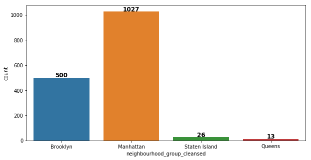

```python
#Number of properties by neighbourhood
plt.figure(figsize=(10, 5))
"""Finding how many properties are there in each neighbourhood group"""
ax = sns.countplot(x="neighbourhood_group_cleansed", data=result)

# The following pice of code for adding labels was taken from stackoverflow
for i, bar in enumerate(ax.patches):
    h = bar.get_height()
    ax.text(
        i, # bar index (x coordinate of text)
        h+18, # y coordinate of text
        '{}'.format(int(h)),  # y label
        ha='center',
        va='center',
        fontweight='bold',
        size=12)
```

#### Observation:

Manhattan has the highest number of properties listed. This may be because of the attractions in it.

Now let's check number of rental properties by zipcode.

[output not shown]

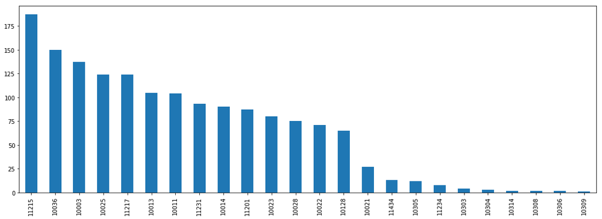

```python
#number of properties by zipcode
plt.figure(figsize=(18,6))
#ax = sns.countplot(x="zipcode", data=result)

result['zipcode'].value_counts().plot(kind='bar')
```

Here we observe that the properties vary largely based on zipcodes. The next piece of code will show us what are the top 5 zipcodes based on the number of properties.

```python
result['zipcode'].value_counts().nlargest(5)
```

```
11215    187
10036    150
10003    137
10025    124
11217    124
Name: zipcode, dtype: int64
```

Next we are going to check the mean price of properties based on the type and the neighbourhood.

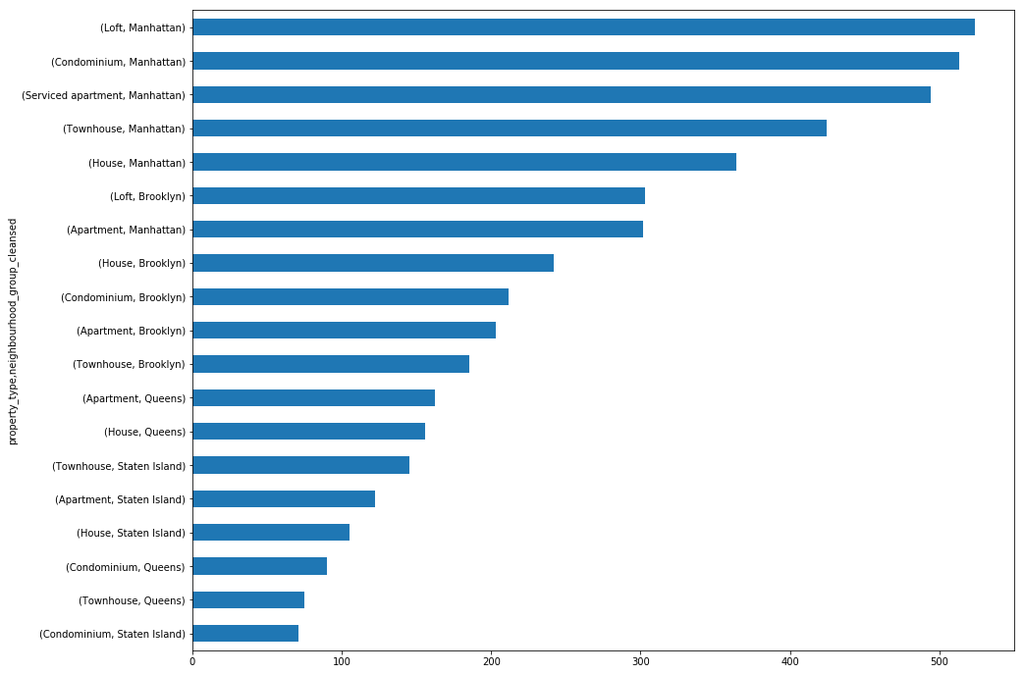

```python
#Mean price of the property by property_type and neighbourhood_group

plt.figure(figsize = (15,12))
result.groupby(["property_type", "neighbourhood_group_cleansed"])["price"].mean().sort_values().plot.barh()
```

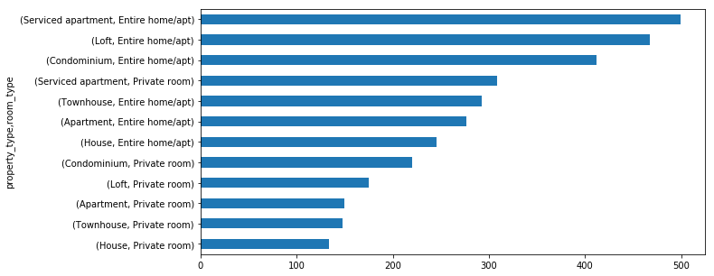

```python
plt.figure(figsize = (10,5))
result.groupby(["property_type", "room_type"])["price"].mean().sort_values().plot.barh()
```

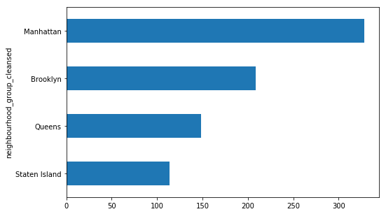

```python
plt.figure(figsize = (8,5))
result.groupby(["neighbourhood_group_cleansed"])["price"].mean().sort_values().plot.barh()
```

#### Observations:

Based on the above charts, we see that

- Manhattan has the highest average rental price. This may be due to two things. 1) the number of rental properties in it and 2) Popularity of the place among visitors
- Whenever an entire home is rented, the average price is high

Now, let's see how the cost of the properties vary according to the neighbourhood and zipcode.

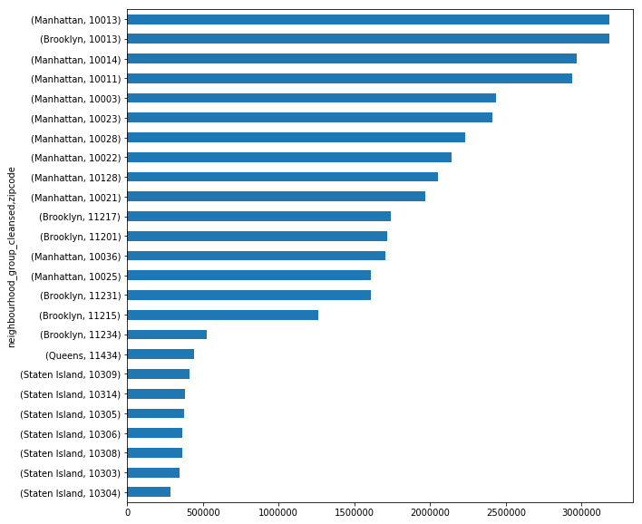

```python
plt.figure(figsize = (10,10))
result.groupby(["neighbourhood_group_cleansed", "zipcode"])["Avg. Median Price"].mean().sort_values().plot.barh()
```

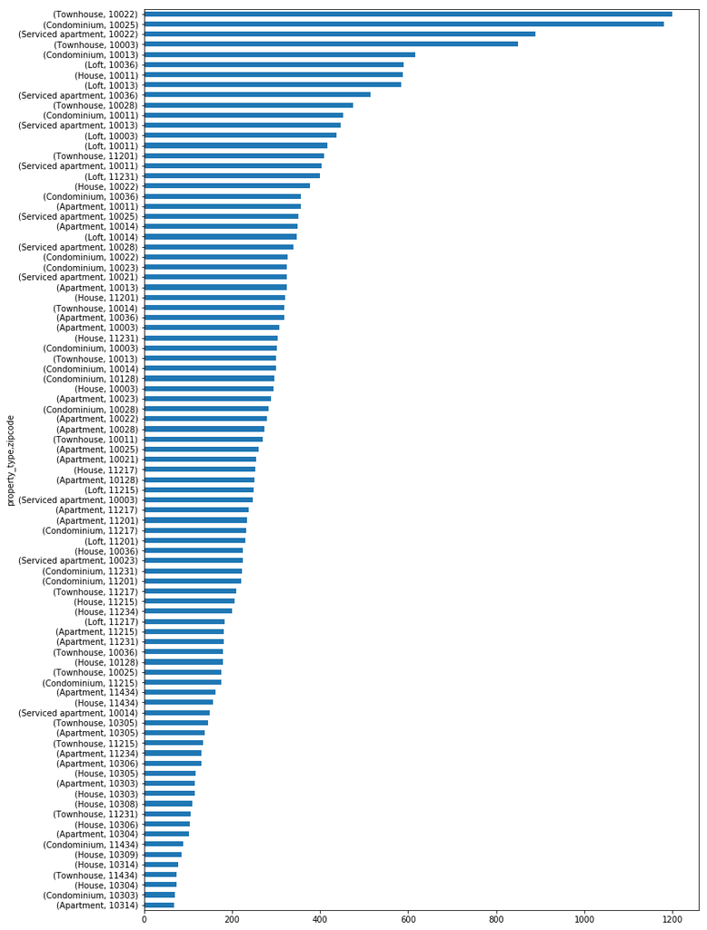

```python
plt.figure(figsize = (12,20))
result.groupby(["property_type", "zipcode"])["price"].mean().sort_values().plot.barh()
```

Let's compare the rental property price vs the asset's actual median cost price based on zipcode.

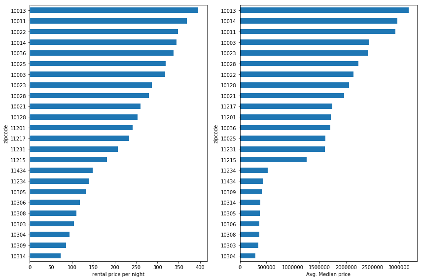

```python
plt.figure(figsize = (12,8))
plt.subplot(1, 2, 1)
result.groupby(["zipcode"])["price"].mean().sort_values().plot.barh()
plt.xlabel('rental price per night')


plt.subplot(1,2,2)
result.groupby(["zipcode"])["Avg. Median Price"].mean().sort_values().plot.barh()
plt.xlabel('Avg. Median price')
plt.tight_layout()
```

The above plot looks interesting! In order to make it better, let's convert rental price per night to annual rental revenue based on the occupany rate.

We are using the following formula to derive the value of the annual rental income for the airbnb property.

Revenue per property and room type = average daily rate *occupancy rate* 365

```python
# Feature Engineering

# New variable "Revenue per property type and per room type"

result.head()
result_new = result.groupby(['property_type', 'room_type',\
                             'neighbourhood_group_cleansed', 'zipcode', 'Avg. Median Price'],\
                            as_index=False)[['price']].mean()
```

```python
#Occupancy rate set as .75

occupancy = 0.75
final = result_new.groupby(['property_type', 'room_type', 'neighbourhood_group_cleansed',\
                            'zipcode', 'Avg. Median Price'])[['price']].sum().reset_index()
final
```

|  | property_type | room_type | neighbourhood_group_cleansed | zipcode | Avg. Median Price | price |
| --- | --- | --- | --- | --- | --- | --- |
| 0 | Apartment | Entire home/apt | Brooklyn | 11201 | 1.72e+06 | 234.89 |
| 1 | Apartment | Entire home/apt | Brooklyn | 11215 | 1.26e+06 | 182.40 |
| 2 | Apartment | Entire home/apt | Brooklyn | 11217 | 1.74e+06 | 243.13 |
| 3 | Apartment | Entire home/apt | Brooklyn | 11231 | 1.61e+06 | 183.73 |
| 4 | Apartment | Entire home/apt | Brooklyn | 11234 | 5.27e+05 | 130.14 |
| 5 | Apartment | Entire home/apt | Manhattan | 10003 | 2.44e+06 | 315.89 |
| 6 | Apartment | Entire home/apt | Manhattan | 10011 | 2.93e+06 | 366.84 |
| 7 | Apartment | Entire home/apt | Manhattan | 10013 | 3.18e+06 | 337.73 |
| 8 | Apartment | Entire home/apt | Manhattan | 10014 | 2.97e+06 | 362.91 |
| 9 | Apartment | Entire home/apt | Manhattan | 10021 | 1.97e+06 | 290.40 |
| 10 | Apartment | Entire home/apt | Manhattan | 10022 | 2.14e+06 | 282.61 |
| 11 | Apartment | Entire home/apt | Manhattan | 10023 | 2.41e+06 | 302.26 |
| 12 | Apartment | Entire home/apt | Manhattan | 10025 | 1.61e+06 | 269.14 |
| 13 | Apartment | Entire home/apt | Manhattan | 10028 | 2.23e+06 | 272.84 |
| 14 | Apartment | Entire home/apt | Manhattan | 10036 | 1.70e+06 | 334.43 |
| 15 | Apartment | Entire home/apt | Manhattan | 10128 | 2.05e+06 | 247.65 |
| 16 | Apartment | Entire home/apt | Queens | 11434 | 4.42e+05 | 162.57 |
| 17 | Apartment | Entire home/apt | Staten Island | 10303 | 3.49e+05 | 115.00 |
| 18 | Apartment | Entire home/apt | Staten Island | 10304 | 2.88e+05 | 102.50 |
| 19 | Apartment | Entire home/apt | Staten Island | 10305 | 3.73e+05 | 137.83 |
| 20 | Apartment | Entire home/apt | Staten Island | 10306 | 3.65e+05 | 130.00 |
| 21 | Apartment | Private room | Brooklyn | 10013 | 3.18e+06 | 100.00 |
| 22 | Apartment | Private room | Brooklyn | 11201 | 1.72e+06 | 200.00 |
| 23 | Apartment | Private room | Brooklyn | 11215 | 1.26e+06 | 146.00 |
| 24 | Apartment | Private room | Brooklyn | 11217 | 1.74e+06 | 122.50 |
| 25 | Apartment | Private room | Brooklyn | 11231 | 1.61e+06 | 72.00 |
| 26 | Apartment | Private room | Manhattan | 10003 | 2.44e+06 | 152.33 |
| 27 | Apartment | Private room | Manhattan | 10011 | 2.93e+06 | 133.50 |
| 28 | Apartment | Private room | Manhattan | 10013 | 3.18e+06 | 182.00 |
| 29 | Apartment | Private room | Manhattan | 10014 | 2.97e+06 | 92.75 |
| ... | ... | ... | ... | ... | ... | ... |
| 89 | Loft | Private room | Manhattan | 10013 | 3.18e+06 | 225.00 |
| 90 | Serviced apartment | Entire home/apt | Manhattan | 10003 | 2.44e+06 | 247.67 |
| 91 | Serviced apartment | Entire home/apt | Manhattan | 10011 | 2.93e+06 | 403.50 |
| 92 | Serviced apartment | Entire home/apt | Manhattan | 10013 | 3.18e+06 | 447.25 |
| 93 | Serviced apartment | Entire home/apt | Manhattan | 10014 | 2.97e+06 | 150.00 |
| 94 | Serviced apartment | Entire home/apt | Manhattan | 10021 | 1.97e+06 | 325.00 |
| 95 | Serviced apartment | Entire home/apt | Manhattan | 10022 | 2.14e+06 | 888.17 |
| 96 | Serviced apartment | Entire home/apt | Manhattan | 10023 | 2.41e+06 | 225.00 |
| 97 | Serviced apartment | Entire home/apt | Manhattan | 10025 | 1.61e+06 | 350.00 |
| 98 | Serviced apartment | Entire home/apt | Manhattan | 10028 | 2.23e+06 | 340.00 |
| 99 | Serviced apartment | Entire home/apt | Manhattan | 10036 | 1.70e+06 | 531.75 |
| 100 | Serviced apartment | Private room | Manhattan | 10036 | 1.70e+06 | 308.00 |
| 101 | Townhouse | Entire home/apt | Brooklyn | 11201 | 1.72e+06 | 410.00 |
| 102 | Townhouse | Entire home/apt | Brooklyn | 11215 | 1.26e+06 | 155.38 |
| 103 | Townhouse | Entire home/apt | Brooklyn | 11217 | 1.74e+06 | 235.89 |
| 104 | Townhouse | Entire home/apt | Brooklyn | 11231 | 1.61e+06 | 125.00 |
| 105 | Townhouse | Entire home/apt | Manhattan | 10003 | 2.44e+06 | 850.00 |
| 106 | Townhouse | Entire home/apt | Manhattan | 10011 | 2.93e+06 | 270.00 |
| 107 | Townhouse | Entire home/apt | Manhattan | 10014 | 2.97e+06 | 318.80 |
| 108 | Townhouse | Entire home/apt | Manhattan | 10022 | 2.14e+06 | 1200.00 |
| 109 | Townhouse | Entire home/apt | Manhattan | 10028 | 2.23e+06 | 650.00 |
| 110 | Townhouse | Entire home/apt | Manhattan | 10036 | 1.70e+06 | 180.00 |
| 111 | Townhouse | Entire home/apt | Staten Island | 10305 | 3.73e+05 | 145.00 |
| 112 | Townhouse | Private room | Brooklyn | 11215 | 1.26e+06 | 93.25 |
| 113 | Townhouse | Private room | Brooklyn | 11217 | 1.74e+06 | 152.00 |
| 114 | Townhouse | Private room | Brooklyn | 11231 | 1.61e+06 | 88.00 |
| 115 | Townhouse | Private room | Manhattan | 10013 | 3.18e+06 | 300.00 |
| 116 | Townhouse | Private room | Manhattan | 10025 | 1.61e+06 | 175.00 |
| 117 | Townhouse | Private room | Manhattan | 10028 | 2.23e+06 | 299.00 |
| 118 | Townhouse | Private room | Queens | 11434 | 4.42e+05 | 75.00 |

119 rows × 6 columns

```python
for i in range(0,len(final.price)):
    final['annual_income'] = final['price'] * occupancy * 365
    final['Net Revenue'] = final['annual_income'] - final['Avg. Median Price']/final['Avg. Median Price']

final.sort_values(by = 'Net Revenue', ascending = False)
```

|  | property_type | room_type | neighbourhood_group_cleansed | zipcode | Avg. Median Price | price | annual_income | Net Revenue |
| --- | --- | --- | --- | --- | --- | --- | --- | --- |
| 47 | Condominium | Entire home/apt | Manhattan | 10025 | 1.61e+06 | 1294.29 | 354310.71 | 354309.71 |
| 108 | Townhouse | Entire home/apt | Manhattan | 10022 | 2.14e+06 | 1200.00 | 328500.00 | 328499.00 |
| 95 | Serviced apartment | Entire home/apt | Manhattan | 10022 | 2.14e+06 | 888.17 | 243135.62 | 243134.62 |
| 105 | Townhouse | Entire home/apt | Manhattan | 10003 | 2.44e+06 | 850.00 | 232687.50 | 232686.50 |
| 109 | Townhouse | Entire home/apt | Manhattan | 10028 | 2.23e+06 | 650.00 | 177937.50 | 177936.50 |
| 43 | Condominium | Entire home/apt | Manhattan | 10013 | 3.18e+06 | 616.67 | 168812.50 | 168811.50 |
| 85 | Loft | Entire home/apt | Manhattan | 10013 | 3.18e+06 | 600.13 | 164285.71 | 164284.71 |
| 87 | Loft | Entire home/apt | Manhattan | 10036 | 1.70e+06 | 590.00 | 161512.50 | 161511.50 |
| 61 | House | Entire home/apt | Manhattan | 10011 | 2.93e+06 | 588.50 | 161101.88 | 161100.88 |
| 99 | Serviced apartment | Entire home/apt | Manhattan | 10036 | 1.70e+06 | 531.75 | 145566.56 | 145565.56 |
| 60 | House | Entire home/apt | Manhattan | 10003 | 2.44e+06 | 495.00 | 135506.25 | 135505.25 |
| 42 | Condominium | Entire home/apt | Manhattan | 10011 | 2.93e+06 | 452.00 | 123735.00 | 123734.00 |
| 92 | Serviced apartment | Entire home/apt | Manhattan | 10013 | 3.18e+06 | 447.25 | 122434.69 | 122433.69 |
| 83 | Loft | Entire home/apt | Manhattan | 10003 | 2.44e+06 | 437.33 | 119720.00 | 119719.00 |
| 84 | Loft | Entire home/apt | Manhattan | 10011 | 2.93e+06 | 417.50 | 114290.62 | 114289.62 |
| 101 | Townhouse | Entire home/apt | Brooklyn | 11201 | 1.72e+06 | 410.00 | 112237.50 | 112236.50 |
| 58 | House | Entire home/apt | Brooklyn | 11231 | 1.61e+06 | 408.33 | 111781.25 | 111780.25 |
| 91 | Serviced apartment | Entire home/apt | Manhattan | 10011 | 2.93e+06 | 403.50 | 110458.12 | 110457.12 |
| 82 | Loft | Entire home/apt | Brooklyn | 11231 | 1.61e+06 | 399.25 | 109294.69 | 109293.69 |
| 54 | Condominium | Private room | Manhattan | 10025 | 1.61e+06 | 380.00 | 104025.00 | 104024.00 |
| 62 | House | Entire home/apt | Manhattan | 10022 | 2.14e+06 | 378.00 | 103477.50 | 103476.50 |
| 6 | Apartment | Entire home/apt | Manhattan | 10011 | 2.93e+06 | 366.84 | 100421.69 | 100420.69 |
| 8 | Apartment | Entire home/apt | Manhattan | 10014 | 2.97e+06 | 362.91 | 99346.04 | 99345.04 |
| 49 | Condominium | Entire home/apt | Manhattan | 10036 | 1.70e+06 | 357.00 | 97728.75 | 97727.75 |
| 97 | Serviced apartment | Entire home/apt | Manhattan | 10025 | 1.61e+06 | 350.00 | 95812.50 | 95811.50 |
| 55 | House | Entire home/apt | Brooklyn | 11201 | 1.72e+06 | 348.33 | 95356.25 | 95355.25 |
| 86 | Loft | Entire home/apt | Manhattan | 10014 | 2.97e+06 | 346.67 | 94900.00 | 94899.00 |
| 98 | Serviced apartment | Entire home/apt | Manhattan | 10028 | 2.23e+06 | 340.00 | 93075.00 | 93074.00 |
| 7 | Apartment | Entire home/apt | Manhattan | 10013 | 3.18e+06 | 337.73 | 92453.96 | 92452.96 |
| 14 | Apartment | Entire home/apt | Manhattan | 10036 | 1.70e+06 | 334.43 | 91549.82 | 91548.82 |
| ... | ... | ... | ... | ... | ... | ... | ... | ... |
| 27 | Apartment | Private room | Manhattan | 10011 | 2.93e+06 | 133.50 | 36545.62 | 36544.62 |
| 4 | Apartment | Entire home/apt | Brooklyn | 11234 | 5.27e+05 | 130.14 | 35626.61 | 35625.61 |
| 20 | Apartment | Entire home/apt | Staten Island | 10306 | 3.65e+05 | 130.00 | 35587.50 | 35586.50 |
| 104 | Townhouse | Entire home/apt | Brooklyn | 11231 | 1.61e+06 | 125.00 | 34218.75 | 34217.75 |
| 88 | Loft | Private room | Brooklyn | 11201 | 1.72e+06 | 125.00 | 34218.75 | 34217.75 |
| 32 | Apartment | Private room | Manhattan | 10023 | 2.41e+06 | 123.33 | 33762.50 | 33761.50 |
| 24 | Apartment | Private room | Brooklyn | 11217 | 1.74e+06 | 122.50 | 33534.38 | 33533.38 |
| 68 | House | Entire home/apt | Staten Island | 10305 | 3.73e+05 | 119.00 | 32576.25 | 32575.25 |
| 17 | Apartment | Entire home/apt | Staten Island | 10303 | 3.49e+05 | 115.00 | 31481.25 | 31480.25 |
| 66 | House | Entire home/apt | Staten Island | 10303 | 3.49e+05 | 115.00 | 31481.25 | 31480.25 |
| 30 | Apartment | Private room | Manhattan | 10021 | 1.97e+06 | 114.60 | 31371.75 | 31370.75 |
| 77 | House | Private room | Staten Island | 10305 | 3.73e+05 | 114.50 | 31344.38 | 31343.38 |
| 78 | House | Private room | Staten Island | 10308 | 3.63e+05 | 109.50 | 29975.62 | 29974.62 |
| 69 | House | Entire home/apt | Staten Island | 10306 | 3.65e+05 | 105.00 | 28743.75 | 28742.75 |
| 18 | Apartment | Entire home/apt | Staten Island | 10304 | 2.88e+05 | 102.50 | 28059.38 | 28058.38 |
| 73 | House | Private room | Brooklyn | 11215 | 1.26e+06 | 100.00 | 27375.00 | 27374.00 |
| 21 | Apartment | Private room | Brooklyn | 10013 | 3.18e+06 | 100.00 | 27375.00 | 27374.00 |
| 76 | House | Private room | Manhattan | 10003 | 2.44e+06 | 95.00 | 26006.25 | 26005.25 |
| 112 | Townhouse | Private room | Brooklyn | 11215 | 1.26e+06 | 93.25 | 25527.19 | 25526.19 |
| 29 | Apartment | Private room | Manhattan | 10014 | 2.97e+06 | 92.75 | 25390.31 | 25389.31 |
| 51 | Condominium | Entire home/apt | Queens | 11434 | 4.42e+05 | 90.00 | 24637.50 | 24636.50 |
| 114 | Townhouse | Private room | Brooklyn | 11231 | 1.61e+06 | 88.00 | 24090.00 | 24089.00 |
| 70 | House | Entire home/apt | Staten Island | 10309 | 4.09e+05 | 85.00 | 23268.75 | 23267.75 |
| 71 | House | Entire home/apt | Staten Island | 10314 | 3.80e+05 | 78.00 | 21352.50 | 21351.50 |
| 67 | House | Entire home/apt | Staten Island | 10304 | 2.88e+05 | 75.00 | 20531.25 | 20530.25 |
| 118 | Townhouse | Private room | Queens | 11434 | 4.42e+05 | 75.00 | 20531.25 | 20530.25 |
| 25 | Apartment | Private room | Brooklyn | 11231 | 1.61e+06 | 72.00 | 19710.00 | 19709.00 |
| 52 | Condominium | Entire home/apt | Staten Island | 10303 | 3.49e+05 | 71.00 | 19436.25 | 19435.25 |
| 36 | Apartment | Private room | Staten Island | 10314 | 3.80e+05 | 68.00 | 18615.00 | 18614.00 |
| 53 | Condominium | Private room | Brooklyn | 11215 | 1.26e+06 | 60.00 | 16425.00 | 16424.00 |

119 rows × 8 columns

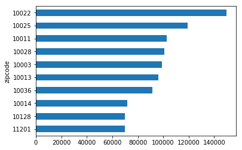

```python
# Groupby zipcode to find what are the top profitable zipcodes
final.groupby(['zipcode'])['Net Revenue'].mean().nlargest(10).sort_values().plot.barh()
```

When zipcodes are alone considered primarily, the following are the top 5 profitable zipcodes in terms of the Net Revenue.

- 1) 10022
- 2) 10025
- 3) 10011
- 4) 10028
- 5) 10003

Let's see what happens if we consider neighbourhood group.

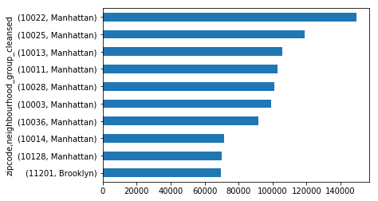

```python
final.groupby(['zipcode', 'neighbourhood_group_cleansed'])['Net Revenue'].mean().nlargest(10).sort_values().plot.barh()
```

Well, that's insightful. We see a slight variation in the order. Now the top 5 most profitable zipcodes are

- 1) 10022
- 2) 10025
- 3) 10013
- 4) 10011
- 5) 10028

All the top ones correspond to Manhattan. Zipcode 10022 is till the topmost in terms of profit.

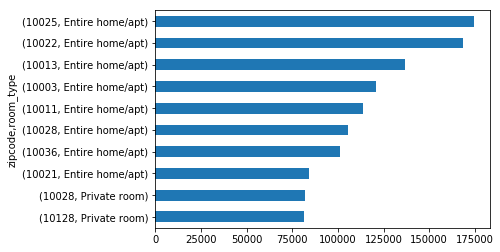

```python
final.groupby(['zipcode', 'room_type'])['Net Revenue'].mean().nlargest(10).sort_values().plot.barh()
```

When we compare profits based on room_type and zipcode, we observe that 10025 is the most profitable when the investor rents an entire home/apartment.

## Conclusion:

Here are the final results of the overall analysis.

We considered these variables to get a broader perspective which will help the realtor in deciding not only the zipcode he needs to invest upon but also other important information on what kind of property and which neighbourhood he should consider.

**Note:** All the above results are based on the assumption that the occupancy rate is 75%